# Multi Target Classification - Lab

Richard Chukwu

# 1 Load the required packages

```r
library(dplyr) # for data manipulation
library(tidyr) # for data manipulation
library(ggplot2) # for data visualization
library(gmodels) # provides the CrossTable()
library(keras) # for the deep learning part
library(tfruns) # to separate our parameters from the model architecture
set.seed(123) # set seed for reproducibility

source("functions/train_val_test_split.R") # load the required partition function
```

## 1.1 Data Preparation

In this section describe our data and prepare it for the network

### 1.1.1 Data description

In this exercise, we apply deep neural network for a classification task. The dataset used can be found on the UCI Machine Learning Repository maintained by the School of Information and Computer Science at the University of California. You can access this at https://archive.ics.uci.edu/ml/datasets/cardiotocography. This data consists of fetal CTGs, and the target variable classifies a patient into one of three categories: normal, suspect, and pathological. There are 2,126 rows in this dataset. The CTGs are classified by three expert obstetricians, and a consensus classification label is assigned to each of them as normal (N) (represented by 1), suspect (S) (represented by 2),and pathological (P) (represented by 3). There are 21 independent variables, and the main objective is to develop a classification model to correctly classify each patient into one of the three classes represented by N, S, and P.

```r
ctg_data <- read.csv('data/ctg_data.csv', sep = ',', header = TRUE)
str(ctg_data)
```

```
## 'data.frame':    2126 obs. of  22 variables:
##  $ LB      : int  120 132 133 134 132 134 134 122 122 122 ...
##  $ AC      : num  0 0.006 0.003 0.003 0.007 0.001 0.001 0 0 0 ...
##  $ FM      : num  0 0 0 0 0 0 0 0 0 0 ...
##  $ UC      : num  0 0.006 0.008 0.008 0.008 0.01 0.013 0 0.002 0.003 ...
##  $ DL      : num  0 0.003 0.003 0.003 0 0.009 0.008 0 0 0 ...
##  $ DS      : num  0 0 0 0 0 0 0 0 0 0 ...
##  $ DP      : num  0 0 0 0 0 0.002 0.003 0 0 0 ...
##  $ ASTV    : int  73 17 16 16 16 26 29 83 84 86 ...
##  $ MSTV    : num  0.5 2.1 2.1 2.4 2.4 5.9 6.3 0.5 0.5 0.3 ...
##  $ ALTV    : int  43 0 0 0 0 0 0 6 5 6 ...
##  $ MLTV    : num  2.4 10.4 13.4 23 19.9 0 0 15.6 13.6 10.6 ...
##  $ Width   : int  64 130 130 117 117 150 150 68 68 68 ...
##  $ Min     : int  62 68 68 53 53 50 50 62 62 62 ...
##  $ Max     : int  126 198 198 170 170 200 200 130 130 130 ...
##  $ Nmax    : int  2 6 5 11 9 5 6 0 0 1 ...
##  $ Nzeros  : int  0 1 1 0 0 3 3 0 0 0 ...
##  $ Mode    : int  120 141 141 137 137 76 71 122 122 122 ...
##  $ Mean    : int  137 136 135 134 136 107 107 122 122 122 ...
##  $ Median  : int  121 140 138 137 138 107 106 123 123 123 ...
##  $ Variance: int  73 12 13 13 11 170 215 3 3 1 ...
##  $ Tendency: int  1 0 0 1 1 0 0 1 1 1 ...
##  $ NSP     : int  2 1 1 1 1 3 3 3 3 3 ...
```

### 1.1.2 Normalization of numeric variables

First we convert our data to a matrix, and strip of the variable names. then we use the normalize function from the keras package. the target class is also converted into a numeric format.

```r
ctg_matrix <- as.matrix(ctg_data)
dimnames(ctg_matrix) <- NULL
ctg_matrix[,1:21] <- normalize(ctg_matrix[,1:21])
ctg_matrix[,22] <- as.numeric(ctg_matrix[,22]) -1 # we start the target values at zero
```

### 1.1.3 Data partitioning

Here we split our matrix data and label into a training and test set

```r
c(train, val, test) %<-% train_val_test_split(df = ctg_matrix,
                                              train_ratio = 0.7,
                                              val_ratio = 0.0,
                                              test_ratio = 0.3)

trainX <- train[ ,1:21]
trainY <- train[ ,22]
testX <- test[, 1:21]
testY <- test[ ,22]
```

### 1.1.4 One hot encoding

This enables us to represent a categorical variable as a binary class numeric matrix where the presence or absence of a class is simply represented by 1 or 0 respectively. we use the *to_categorical* function form the keras package.

```r
trainLabels <- to_categorical(trainY)
testLabels <- to_categorical(testY)
print(testLabels[1:10,])
```

```
##       [,1] [,2] [,3]
##  [1,]    1    0    0
##  [2,]    1    0    0
##  [3,]    0    0    1
##  [4,]    1    0    0
##  [5,]    0    0    1
##  [6,]    1    0    0
##  [7,]    0    0    1
##  [8,]    1    0    0
##  [9,]    1    0    0
## [10,]    1    0    0
```

## 1.2 Model Creation

### 1.2.1 Building our model architecture

```r
create_model_one <- function() {
  keras_model_sequential() %>%
    layer_dense(units = 8,
               activation = "relu",
               input_shape = c(21)) %>%
    layer_dense(units = 3, activation = "softmax") %>% # 3 stands for the target classes
    compile(loss = "categorical_crossentropy",
            optimizer = "adam",
            metrics = "accuracy")
}
```

```r
net1 <- create_model_one()
history <- net1 %>%
  fit(x = trainX,
      y = trainLabels,
      batch_size = 32,
      epochs = 200,
      validation_split = 0.2,
      callbacks = callback_tensorboard('ctg/one'))
```

Points to note: if the training data accuracy increases with the number of epochs, but the validation data accuracy decreases, that would suggest an overfitting of the model.

```r
tensorboard('ctg/one')
```

```
## Started TensorBoard at http://127.0.0.1:6922
```

### 1.2.2 Model Evaluation

Here we assume the model loss and accuracy

```r
net1 %>%
evaluate(testX, testLabels)
```

```
## $loss
## [1] 0.4438524
##
## $accuracy
## [1] 0.8291536
```

```r
colSums(testLabels)
```

```
## [1] 483  96  59
```

Converting to percentages

```r
prop.table(table(trainY))
```

```
## trainY
##          0          1          2
## 0.78763441 0.13373656 0.07862903
```

```r
prop.table(table(testY))
```

```
## testY
##          0          1          2
## 0.75705329 0.15047022 0.09247649
```

```r
# (colSums(testLabels)/638) * 100
```

Using the colSums() to find the percentages of the different target classes, we can see that the highest number of samples belongs to the normal category of patients. we can use $75.7\%$ as abenchmark for the model performance. If we do not use any model and simply classify all cases in the test data as belonging to the normal category of patients, then we will still be correct about $75.7\%$ of the time since we will be right about all normal patients and incorrect about the other two categories.

$75.7\%$, therefore, serves as our benchmark.

### 1.2.3 Confusion matrix

For the predictions we use the predict_classes() from keras package.

```r
predY <- net1 %>%
  predict_classes(testX)
```

Using the CrossTable() from the gmodels package

```r
CrossTable(predY, testY,
           prop.chisq = FALSE, prop.c = FALSE, prop.r = FALSE,
           dnn = c('predicted', 'actual'))
```

```
##
##
##    Cell Contents
## |-------------------------|
## |                       N |
## |         N / Table Total |
## |-------------------------|
##
##
## Total Observations in Table:  638
##
##
##              | actual
##    predicted |         0 |         1 |         2 | Row Total |
## -------------|-----------|-----------|-----------|-----------|
##            0 |       466 |        49 |        17 |       532 |
##              |     0.730 |     0.077 |     0.027 |           |
## -------------|-----------|-----------|-----------|-----------|
##            1 |        17 |        47 |        26 |        90 |
##              |     0.027 |     0.074 |     0.041 |           |
## -------------|-----------|-----------|-----------|-----------|
##            2 |         0 |         0 |        16 |        16 |
##              |     0.000 |     0.000 |     0.025 |           |
## -------------|-----------|-----------|-----------|-----------|
## Column Total |       483 |        96 |        59 |       638 |
## -------------|-----------|-----------|-----------|-----------|
##
##
```

```r
prob <- net1 %>%
  predict_proba(testX)
cbind(prob, predY, testY)[1:5,]
```

```
##                                         predY testY
## [1,] 0.9932788 0.006249091 0.0004720882     0     0
## [2,] 0.9930266 0.006599120 0.0003743563     0     0
## [3,] 0.3452317 0.248731911 0.4060364068     2     2
## [4,] 0.9512290 0.038272683 0.0104982434     0     0
## [5,] 0.5710878 0.176461548 0.2524506152     0     2
```

## 1.3 Performance Optimization

### 1.3.1 Addition of an extra hidden layer

The first optimization we carry out is to add an additional hidden layer ot our previous model *net1*.

Here we set up our model function

```r
create_model_two <- function() {
  keras_model_sequential() %>%
    layer_dense(units = 8,
               activation = "relu",
               input_shape = c(21)) %>%
    layer_dense(units = 5, activation = "relu") %>% # second hidden layer with 5 units
    layer_dense(units = 3, activation = "softmax") %>% # 3 stands for the target classes

    compile(loss = "categorical_crossentropy",
            optimizer = "adam",
            metrics = "accuracy")
}
```

Here the model is created and fitted.

The history2 stores the model output related information.

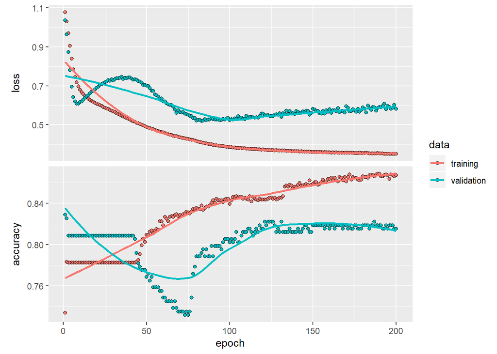

```r
net2 <- create_model_two()
history2 <- net2 %>%
  fit(x = trainX,
      y = trainLabels,
      batch_size = 32,
      epochs = 200,
      validation_split = 0.2,
      callbacks = callback_tensorboard('ctg/two'))

plot(history2)
```

#### 1.3.1.1 Model Evaluation

In this section we create predictions based on our test data

```r
predY <- net2 %>%
predict_classes(testX)

net2 %>%
evaluate(testX, testLabels)
```

```
## $loss
## [1] 0.4090277
##
## $accuracy
## [1] 0.862069
```

#### 1.3.1.2 Confusion Matrix

```r
CrossTable(predY, testY,
           prop.chisq = FALSE, prop.c = FALSE, prop.r = FALSE,
           dnn = c('predicted', 'actual'))
```

```
##
##
##    Cell Contents
## |-------------------------|
## |                       N |
## |         N / Table Total |
## |-------------------------|
##
##
## Total Observations in Table:  638
##
##
##              | actual
##    predicted |         0 |         1 |         2 | Row Total |
## -------------|-----------|-----------|-----------|-----------|
##            0 |       464 |        52 |        10 |       526 |
##              |     0.727 |     0.082 |     0.016 |           |
## -------------|-----------|-----------|-----------|-----------|
##            1 |        14 |        44 |         7 |        65 |
##              |     0.022 |     0.069 |     0.011 |           |
## -------------|-----------|-----------|-----------|-----------|
##            2 |         5 |         0 |        42 |        47 |
##              |     0.008 |     0.000 |     0.066 |           |
## -------------|-----------|-----------|-----------|-----------|
## Column Total |       483 |        96 |        59 |       638 |
## -------------|-----------|-----------|-----------|-----------|
##
##
```

### 1.3.2 Increasing the number of units in the first hidden layer

The second optimization we carry out is to increase the number of units in our first hidden layer ot our previous model *net2*.

Here we set up our model function

```r
create_model_three <- function() {
  keras_model_sequential() %>%
    layer_dense(units = 30,
               activation = "relu",
               input_shape = c(21)) %>%
    layer_dense(units = 5, activation = "relu") %>% # second hidden layer with 5 units
    layer_dense(units = 3, activation = "softmax") %>% # 3 stands for the target classes

    compile(loss = "categorical_crossentropy",
            optimizer = "adam",
            metrics = "accuracy")
}
```

Here the model is created and fitted.

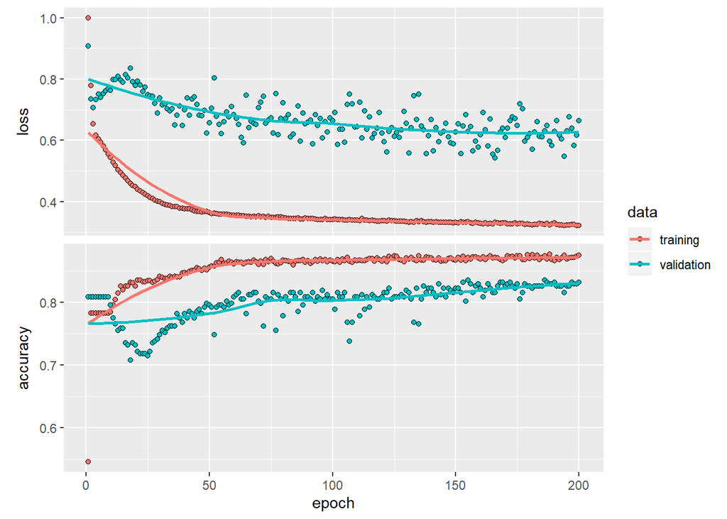

```r
net3 <- create_model_three()
history3 <- net3 %>%
  fit(x = trainX,
      y = trainLabels,
      batch_size = 32,
      epochs = 200,
      validation_split = 0.2,
      callbacks = callback_tensorboard('ctg/three'))

plot(history3)
```

#### 1.3.2.1 Model evaluation

In this section we create predictions based on our test data

```r
predY <- net3 %>%
predict_classes(testX)

net3 %>%
evaluate(testX, testLabels)
```

```
## $loss
## [1] 0.3979682
##
## $accuracy
## [1] 0.8636364
```

Confusion MATRIX

```r
CrossTable(predY, testY,
           prop.chisq = FALSE, prop.c = FALSE, prop.r = FALSE,
           dnn = c('predicted', 'actual'))
```

```
##
##
##    Cell Contents
## |-------------------------|
## |                       N |
## |         N / Table Total |
## |-------------------------|
##
##
## Total Observations in Table:  638
##
##
##              | actual
##    predicted |         0 |         1 |         2 | Row Total |
## -------------|-----------|-----------|-----------|-----------|
##            0 |       452 |        42 |         7 |       501 |
##              |     0.708 |     0.066 |     0.011 |           |
## -------------|-----------|-----------|-----------|-----------|
##            1 |        24 |        53 |         6 |        83 |
##              |     0.038 |     0.083 |     0.009 |           |
## -------------|-----------|-----------|-----------|-----------|
##            2 |         7 |         1 |        46 |        54 |
##              |     0.011 |     0.002 |     0.072 |           |
## -------------|-----------|-----------|-----------|-----------|
## Column Total |       483 |        96 |        59 |       638 |
## -------------|-----------|-----------|-----------|-----------|
##
##
```

### 1.3.3 Guarding against the inbalance problem, adding additional hidden layers.

A careful examination of our original data set shows an imbalance of the classes

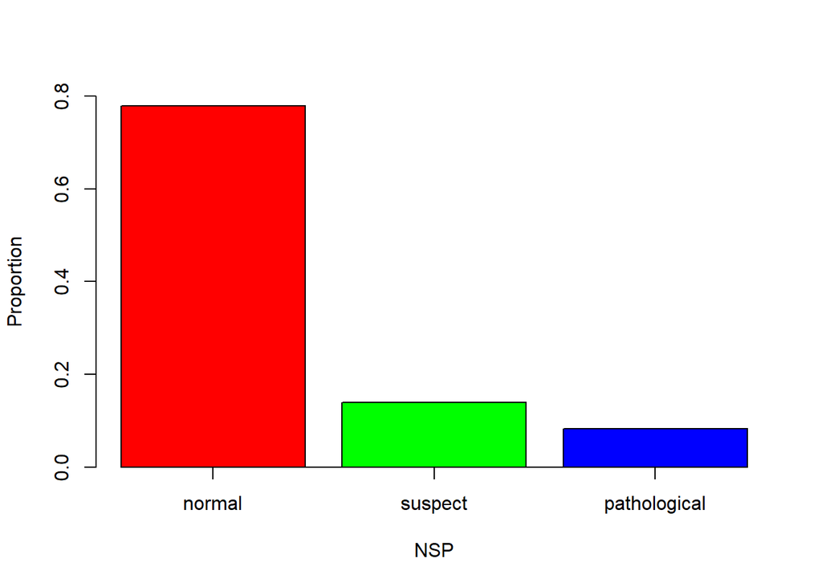

```r
barplot(prop.table(table(ctg_data$NSP)),
col = rainbow(3),
ylim = c(0, 0.8),
ylab = 'Proportion',
xlab = 'NSP',
cex.names = 1.5,
xaxt = "n")
axis(1, at=c(0.7,1.9,3.1), labels= c("normal", "suspect", "pathological"))
```

From the bar plot we estiimate the percentages of normal, suspect, and pathological patients as approximately 78%, 14%, and 8% respectively. Ananlysis of the target classes shows that the number of normal patients is about 5.6 times (1,655/295) greater than the number of suspect patients and about 9.4 times greater than the number of pathological patients. The dataset exhibits a pattern where classes are not balanced. This could result in a classification model that is biased towards the class with the highest number of observations. To address this problem, we make use of class weights while building our model.

Here we set up our model function

In this new model we have added a dropout layer with dropout rates of 40%, 30%, and 20%. For instance, with a dropout rate of 0.4 (or 40%) after the first hidden layer, 40% of the units in the first hidden layer are randomly dropped to zero during network training. This helps to avoid any overfitting that may occur because of the higher number of units in the hidden layers.

```r
create_model_four <- function() {
  keras_model_sequential() %>%
    layer_dense(units = 40,
               activation = "relu",
               input_shape = c(21)) %>%
    layer_dropout(rate = 0.4) %>%
    layer_dense(units = 30, activation = "relu") %>% # second hidden layer with 5 units

    layer_dropout(rate = 0.3) %>%
    layer_dense(units = 8, activation = "relu") %>%
    layer_dropout(rate = 0.2) %>%
    layer_dense(units = 3, activation = "softmax") %>% # 3 stands for the target classes
    compile(loss = "categorical_crossentropy",
            optimizer = "adam",
            metrics = "accuracy")
}
```

Here the model is created and fitted.

The history4 stores the model output related information.

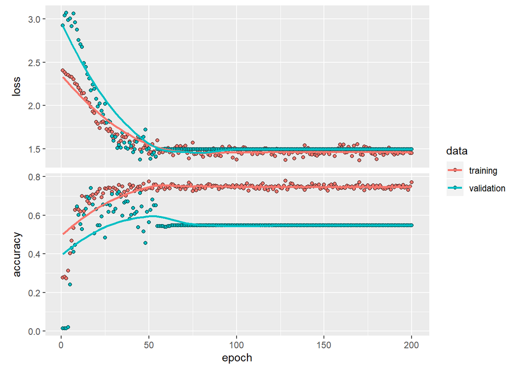

```r
net4 <- create_model_four()
history4 <- net4 %>%
  fit(x = trainX,
      y = trainLabels,
      batch_size = 32,
      epochs = 200,
      validation_split = 0.2,
      class_weight = list("0" = 1,"1"= 5.6, "2" = 9.4),
      callbacks = list(callback_tensorboard('ctg/five'),
                       callback_reduce_lr_on_plateau(factor = 0.01)))

plot(history4)
```

- from the accuracy plot we see a plateau in both the training and validation data after 52 epochs.

#### 1.3.3.1 Model evaluation

In this section we create predictions based on our test data

```r
predY <- net4 %>%
predict_classes(testX)

net4 %>%
evaluate(testX, testLabels)
```

```
## $loss
## [1] 0.6106147
##
## $accuracy
## [1] 0.7868339
```

Confusion MATRIX

```r
CrossTable(predY, testY,
           prop.chisq = FALSE, prop.c = FALSE, prop.r = FALSE,
           dnn = c('predicted', 'actual'))
```

```
##
##
##    Cell Contents
## |-------------------------|
## |                       N |
## |         N / Table Total |
## |-------------------------|
##
##
## Total Observations in Table:  638
##
##
##              | actual
##    predicted |         0 |         1 |         2 | Row Total |
## -------------|-----------|-----------|-----------|-----------|
##            0 |       374 |        12 |         1 |       387 |
##              |     0.586 |     0.019 |     0.002 |           |
## -------------|-----------|-----------|-----------|-----------|
##            1 |        87 |        76 |         6 |       169 |
##              |     0.136 |     0.119 |     0.009 |           |
## -------------|-----------|-----------|-----------|-----------|
##            2 |        22 |         8 |        52 |        82 |
##              |     0.034 |     0.013 |     0.082 |           |
## -------------|-----------|-----------|-----------|-----------|
## Column Total |       483 |        96 |        59 |       638 |
## -------------|-----------|-----------|-----------|-----------|
##
##
```

## 1.4 Saving the Final Model

```r
# Save and reload model
save_model_hdf5(net4,
filepath = "model/net_82" ,
overwrite = TRUE,
include_optimizer = TRUE)
```

# 2 Hyperparameter Tuning

Now we could move forward and adapt

- network topology,
- count of layers,
- type of layers,
- count of nodes per layer,
- loss function,
- activation function,
- learning rate,
- and much more, …

Play around with the parameters and see how they impact the result.